# Text Data Mining

Hyunah Ahn

# Intro

## Text Data Mining

- **Course Objectives**: By the end of the semester, Ss will be able to…
  - Preprocess text data for analysis using R (or Python)
  - Visualize relationships between words and documents
  - Apply computational linguistics concepts (Zipf’s law, tf-idf, LDA) to conducting *sentiment analysis* and *topic modeling*
- **Data**: Texts in Project Gutenberg
- **Software**: R (or Python)

The course assumes no prior knowledge on programming or statistics.

## Weekly Topics

- Week 1: Course overview
- Week 2: How to use R (and Rstudio)
- Week 3: Project Gutenberg
- Week 4: Understanding “tidy text” and preprocessing text.
- Week 5: Tokenizing text
- **Week 6: Word frequency and Zipf’s law**
- Week 7: Midterm
- Week 8: Project Workshop
- Week 9: Data visualization
- Week 10: Sentiment Analysis
- Week 11: Term Frequency (and Inverse Document Frequency)
- Week 12: Latent Dirichlet Allocation
- Week 13: Topic Modeling
- Week 14: Presentations
- Week 15: Final exam

## Today

**Review (Weeks 1-5)**

- Project Gutenberg
- Tidying, preprocessing, and tokenizing text

**Word Frequency and Zipf’s law (Week 6)**

- Counting words in Jane Austen’s “Pride and Prejudice”
- Ranking the word frequency
- Plotting word frequency and rank
- Zipf’s law
- Assignment

# Review

## Project Gutenberg

- **Free Digital Library**: A collection of over 70,000 free eBooks, including classic literature and historical texts (www.gutenberg.org)
- **Accessible Text Data**: Invaluable for linguistics and text analysis (plain-text versions of books, easy to process computationally)
- **Packages available in both R and python**: gutenbergr (R) and Gutenberg (python)

## Pride & Prejudice

```r
library(janeaustenr)
library(tidytext)
library(tidyverse)
pride <- janeaustenr::austen_books()%>%
  filter(book=="Pride & Prejudice")
print(pride, n=15)
```

```
# A tibble: 13,030 × 2
   text                                                                    book
   <chr>                                                                   <fct>
 1 "PRIDE AND PREJUDICE"                                                   Prid…
 2 ""                                                                      Prid…
 3 "By Jane Austen"                                                        Prid…
 4 ""                                                                      Prid…
 5 ""                                                                      Prid…
 6 ""                                                                      Prid…
 7 "Chapter 1"                                                             Prid…
 8 ""                                                                      Prid…
 9 ""                                                                      Prid…
10 "It is a truth universally acknowledged, that a single man in possessi… Prid…
11 "of a good fortune, must be in want of a wife."                         Prid…
12 ""                                                                      Prid…
13 "However little known the feelings or views of such a man may be on hi… Prid…
14 "first entering a neighbourhood, this truth is so well fixed in the mi… Prid…
15 "of the surrounding families, that he is considered the rightful prope… Prid…
# ℹ 13,015 more rows
```

The raw form of data is “messy” and cannot be analyzed as is.

## Tidying & Preprocessing Text

```r
pride1<-pride %>%
  # Detect lines that mark the beginning of a chapter
  mutate(chapter_start = str_detect(text, regex("^(Chapter|CHAPTER)\\s+[IVXLCDM0-9]+", ignore_case = TRUE)))%>%
  # Assign a chapter number based on where chapters start
  mutate(chapter = cumsum(chapter_start)) %>%
  # Remove the temporary chapter_start column
  select(book, chapter, text) %>%
  # Filter out any pre-chapter text or rows without valid chapter content
  filter(chapter > 0)%>%
  mutate(text = str_replace_all(text, "[:punct:]|\\d", " ")) %>%
  filter(!str_detect(text, regex("^\\s*$")), # Remove empty lines
         !str_detect(text, regex("^(Chapter|CHAPTER)\\s", ignore_case = TRUE)) )%>% # Remove chapter titles
  mutate(text = str_squish(text)) %>%
  select(-chapter)

print(pride1, n=10)
```

```
# A tibble: 10,652 × 2
   book              text
   <fct>             <chr>
 1 Pride & Prejudice It is a truth universally acknowledged that a single man i…
 2 Pride & Prejudice of a good fortune must be in want of a wife
 3 Pride & Prejudice However little known the feelings or views of such a man m…
 4 Pride & Prejudice first entering a neighbourhood this truth is so well fixed…
 5 Pride & Prejudice of the surrounding families that he is considered the righ…
 6 Pride & Prejudice of some one or other of their daughters
 7 Pride & Prejudice My dear Mr Bennet said his lady to him one day have you he…
 8 Pride & Prejudice Netherfield Park is let at last
 9 Pride & Prejudice Mr Bennet replied that he had not
10 Pride & Prejudice But it is returned she for Mrs Long has just been here and…
# ℹ 10,642 more rows
```

## Tokenizing Text

```r
pride_words<-pride1%>%
  unnest_tokens(word, text)

print(pride_words, n=15)
```

```
# A tibble: 122,750 × 2
   book              word
   <fct>             <chr>
 1 Pride & Prejudice it
 2 Pride & Prejudice is
 3 Pride & Prejudice a
 4 Pride & Prejudice truth
 5 Pride & Prejudice universally
 6 Pride & Prejudice acknowledged
 7 Pride & Prejudice that
 8 Pride & Prejudice a
 9 Pride & Prejudice single
10 Pride & Prejudice man
11 Pride & Prejudice in
12 Pride & Prejudice possession
13 Pride & Prejudice of
14 Pride & Prejudice a
15 Pride & Prejudice good
# ℹ 122,735 more rows
```

**What is tidy data?**

1. A column is a variable.
2. A row is an observation.
3. A cell is a value.

“Happy families are all alike; every unhappy family is unhappy in its own way.” — Leo Tolstoy

“Tidy datasets are all alike, but every messy dataset is messy in its own way.” — Hadley Wickham

In the previous five weeks, the course has covered the topics just briefed.

# Week 6

## Table of Contents

- Word frequency in “Pride & Prejudice”
- Ranking the word frequency
- Plotting word frequency and rank
- Zipf’s law

## Counting words in “Pride & Prejudice”

```r
pride_words<-pride1%>%
  unnest_tokens(word, text)

print(pride_words, n=15)
```

```
# A tibble: 122,750 × 2
   book              word
   <fct>             <chr>
 1 Pride & Prejudice it
 2 Pride & Prejudice is
 3 Pride & Prejudice a
 4 Pride & Prejudice truth
 5 Pride & Prejudice universally
 6 Pride & Prejudice acknowledged
 7 Pride & Prejudice that
 8 Pride & Prejudice a
 9 Pride & Prejudice single
10 Pride & Prejudice man
11 Pride & Prejudice in
12 Pride & Prejudice possession
13 Pride & Prejudice of
14 Pride & Prejudice a
15 Pride & Prejudice good
# ℹ 122,735 more rows
```

- Number of Types (w/o repeats)

```r
type<-length(unique(pride_words$word))
```

6257 words

- Number of Tokens (w/ repeats)

```r
token<-nrow(pride_words)
```

122750 words

- Type-Token Ratio

```r
ttr<-round((type/token)*100, digits = 2)
```

5.1% $\approx$ 1:20

## Most and Least Frequent Words

```r
pride_wordCount<-pride_words %>% count(word, sort = TRUE)
```

```r
print(pride_wordCount,
      n=Inf)
```

```
# A tibble: 6,257 × 2
     word                  n
     <chr>             <int>
   1 the                4331
   2 to                 4163
   3 of                 3611
   4 and                3584
   5 her                2225
   6 i                  2070
   7 a                  1954
   8 in                 1880
   9 was                1846
  10 she                1710
  11 that               1579
  12 it                 1535
```

[output cut: 6245 more lines]

```r
print(pride_wordCount[nrow(pride_wordCount):1,
                      ], n=Inf)
```

```
# A tibble: 6,257 × 2
     word                  n
     <chr>             <int>
   1 youths                1
   2 york                  1
   3 yawning               1
   4 yawned                1
   5 yards                 1
   6 writes                1
   7 wretchedly            1
   8 worthlessness         1
   9 womanly               1
  10 woe                   1
  11 wives                 1
  12 witty                 1
```

[output cut: 6245 more lines]

- Q. How many words were used more than 4000 times? 1000 times?
- Q. How about fewer than 10 times? Or just once?

## Proportion of frequent and rare words

Words used > 1000 times

```r
thousand<-pride_wordCount%>%filter(n>1000); ttype<-nrow(thousand)
fst<-sum(thousand$n)
type22<-round((ttype/nrow(pride_wordCount))*100, digits = 2)
token22<-round((fst/nrow(pride_words))*100, digits = 2)
```

- 22 unique words (types)
- Type ratio: 22/6257 = 0.35%
- Frequency sum = 42596
- Token ratio:
  - 42596/122750 = 34.7%

Words used Fewer than 10 times

```r
fewer10<-pride_wordCount%>%filter(n<10); btype<-nrow(fewer10)
fsb<-sum(fewer10$n)
typeb<-round((btype/nrow(pride_wordCount))*100, digits = 2)
tokenb<-round((fsb/nrow(pride_words))*100, digits = 2)
```

- 5048 unique words (types)
- Type ratio: 5048/6257 = 80.68%
- Frequency sum = 12838
- Token ratio:
  - 12838/122750 = 10.46%

# of types: 6257

# of tokens: 122750

## Distribution of words in a large text

- Frequent words
  - 0.35% (22 words) of all unique words (types = 6257) are used more than 1000 times and make up around 35% of all tokens (= 122,750).
- Infrequent words
  - Around 80% (5048 words) of all unique words (types) are used fewer than 10 times and make up only around 10% of the entire text (tokens).
- Zipfian distribution
  - In a large text, a small number of unique words occur very frequently, while the majority occur rarely, creating a predictable imbalance between word frequency and diversity.

## Discussion Questions

**Frequent Words**

```r
# Words used more than 1000 times
paste(thousand$word, collapse = ", ")
```

```
[1] "the, to, of, and, her, i, a, in, was, she, that, it, not, you, he, his, be, as, had, for, with, but"
```

**Infrequent Words**

```r
# A few examples of words used only once
paste(fewer10$word[5029:5048], collapse = ", ")
```

```
[1] "wisdom, wiser, wisher, withdrawing, withstood, witnessing, wits, witticisms, witty, wives, woe, womanly, worthlessness, wretchedly, writes, yards, yawned, yawning, york, youths"
```

- Which words matter more?
- What would happen if we removed all frequent words?
- What would happen if we removed all infrequent words?

## Ranking word frequency

```r
pride_wordCount1<-pride_wordCount%>%
  mutate(total = sum(n))%>%
  mutate(tf = n/total)%>%
  mutate(rank = rank(-n, ties.method = "min"))
```

```r
 pride_wordCount1 %>%
  arrange(desc(n))%>%
  print(n=15)
```

```
# A tibble: 6,257 × 5
   word      n  total     tf  rank
   <chr> <int>  <int>  <dbl> <int>
 1 the    4331 122750 0.0353     1
 2 to     4163 122750 0.0339     2
 3 of     3611 122750 0.0294     3
 4 and    3584 122750 0.0292     4
 5 her    2225 122750 0.0181     5
 6 i      2070 122750 0.0169     6
 7 a      1954 122750 0.0159     7
 8 in     1880 122750 0.0153     8
 9 was    1846 122750 0.0150     9
10 she    1710 122750 0.0139    10
11 that   1579 122750 0.0129    11
12 it     1535 122750 0.0125    12
13 not    1429 122750 0.0116    13
14 you    1358 122750 0.0111    14
15 he     1336 122750 0.0109    15
# ℹ 6,242 more rows
```

```r
pride_wordCount1 %>%
  arrange(n, desc(word))%>%
  print(n=15)
```

```
# A tibble: 6,257 × 5
   word              n  total         tf  rank
   <chr>         <int>  <int>      <dbl> <int>
 1 youths            1 122750 0.00000815  3896
 2 york              1 122750 0.00000815  3896
 3 yawning           1 122750 0.00000815  3896
 4 yawned            1 122750 0.00000815  3896
 5 yards             1 122750 0.00000815  3896
 6 writes            1 122750 0.00000815  3896
 7 wretchedly        1 122750 0.00000815  3896
 8 worthlessness     1 122750 0.00000815  3896
 9 womanly           1 122750 0.00000815  3896
10 woe               1 122750 0.00000815  3896
11 wives             1 122750 0.00000815  3896
12 witty             1 122750 0.00000815  3896
13 witticisms        1 122750 0.00000815  3896
14 wits              1 122750 0.00000815  3896
15 witnessing        1 122750 0.00000815  3896
# ℹ 6,242 more rows
```

## Plotting word frequency and rank

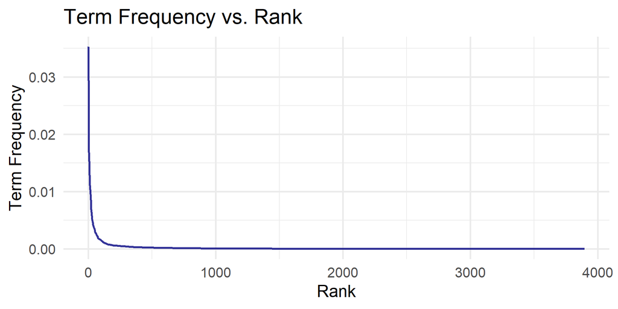

```r
ggplot(pride_wordCount1, aes(rank, tf)) + geom_line(linewidth = 1.1, alpha = 0.8, color = "navy")+
  labs(title = "Term Frequency vs. Rank", x = "Rank", y = "Term Frequency")+theme_minimal(base_size = 20)
```

The relationship is non-linear (or skewed), which means a small number of words are extremely frequent while a great majority of words occur only once or twice.

## Handling skewness: Log transformation

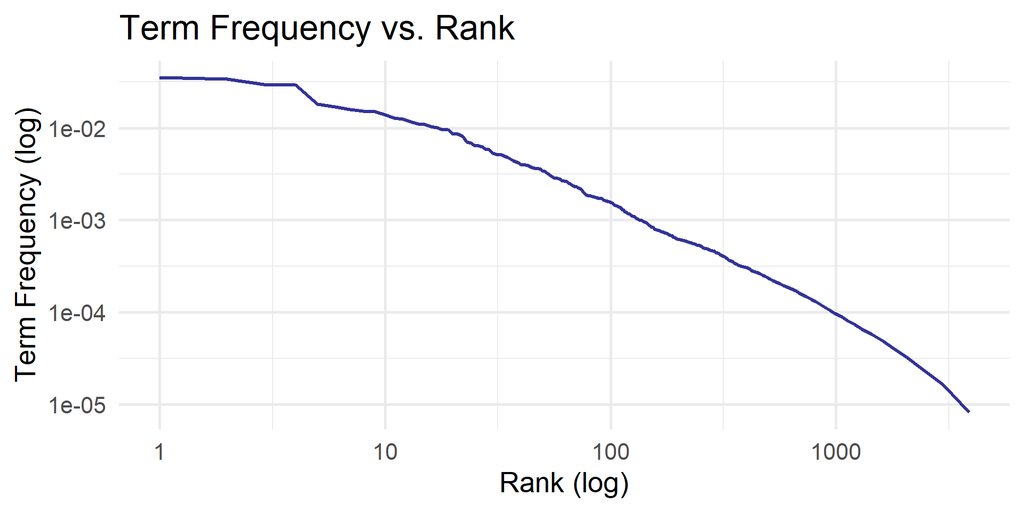

```r
logplot<-ggplot(pride_wordCount1, aes(rank, tf)) + geom_line(linewidth = 1.1, alpha = 0.8, color = "navy")+
  labs(title = "Term Frequency vs. Rank", x = "Rank (log)", y = "Term Frequency (log)")+
  theme_minimal(base_size = 20) + scale_x_log10() + scale_y_log10()
logplot
```

Log transformation highlights the inverse relationship between word frequency and its rank more clearly by scaling the axes to handle the skewed distribution of values.

## Zipf’s law: Definition

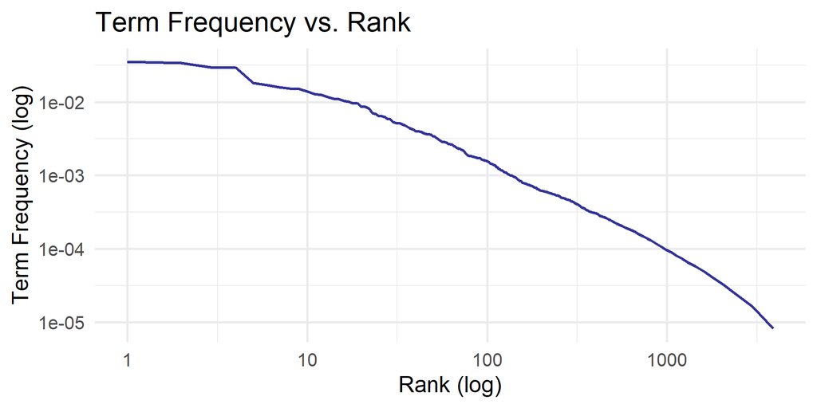

The frequency of a word is inversely proportional to its rank in the frequency table.

$$frequency \propto \frac{1}{rank}$$

**In other words…**

- It shows a pattern in natural language where word frequency decreases as rank increases.
- Few words occur very often, while most appear infrequently.

## Zipf’s law: Why is it important?

**Applications in NLP**

- Knowing how words are distributed improves search engines, sentiment analysis, and topic modeling.
  - Sentiment Analysis: Tone and sentiment of a text is detected.
  - Topic modeling: Text topics can be identified.

**Other Phenomena with Zipfian Distribution**

- City populations
- Species abundance
- Sports statistics
- Music/books/media popularity
- Wealth distribution

## Assignment

- Download a text of your choice from Project Gutenberg.
- Tidy the text data.
- Create a frequency table.
- Plot the frequency and rank in log-log scale.
- Write a short report on frequent and infrequent words.

# Wrap-up

## Text Data Mining

- Ideal for an introductory undergraduate course
- Not only for linguistics (grammatical analysis) but also for literature topics (literature analysis, digital humanities)
- Useful skills for both academic and non-academic tasks

## Thank you!

# Appendix

## Research Areas

**Definiteness processing in L1 and L2 English**

- Ahn, H. & Song, M.-J. (2023). L1 Korean speakers’ definiteness processing in L2 English: A visual world paradigm eye-tracking study. *Bilingualism: Language and Cognition, 26*(3), 556-569.
- Ahn, H. (2022). L2 Processing of linguistic and non-linguistic information: L2 speakers use definiteness if real-world knowledge is unusable. *Studies in Second Language Acquisition, 44*(2), 507-535.
- Ahn, H. (2021). From Interlanguage grammar to target grammar in L2 processing of definiteness as uniqueness. *Second Language Research, 37*(1), 91-119.

**Psych-predicate and thematic role interpretation in Korean and English**

- Ahn, H. & Mariano, G. (accepted). The morphological distribution of English two-place psych predicates in children’s language input. *Studies in English Language & Literature, 50*(4).
- Ahn, H. (2024). The argument drop patterns of the psych-predicate *mwusep-* in spoken, written, and messenger corpora. *Studies in English Language & Literature, 50*(2), 153-173.
- Ahn, H. (2020). L2 Korean speakers’ thematic role resolution in a psych-predicate construction. *Language Research, 56*(2), 141-165.
- Ahn, H. (2018). Prosody, syntax, and discourse: A three-way interaction. *Korean Journal of Linguistics, 43*(1), 73-100.
- Ahn, H. (2017). The prosodic resolution of syntactic/semantic ambiguity: An exemplar-based account. *Language Research, 53*(3), 501-524.